# REN-007 Adjusted Analyses Report

# 1 Population Summary

This report summarizes the evaluable `ITT1FL = "Y"` population and presents adjusted efficacy and post-surgery laboratory analyses for `Placebo` and `RBT-1`.

## 1.1 Statistical Analysis

This study was a phase 3, randomized, double-blind, placebo-controlled study evaluating the effect of RBT-1 on reducing the risk of postoperative complications in subjects undergoing cardiac surgery. All analyses in this report were conducted using the Analysis Data Model (ADaM) datasets supplied for study. The primary analytic population was the evaluable intent-to-treat population (`ITT1FL = "Y"`), defined in the ADaM metadata as randomized subjects with both treatment start and surgery date available. Planned treatment assignment (`TRT01P`/`TRTP`) was used to define the comparison groups, placebo and RBT-1.

Adjusted efficacy analyses incorporated pre-surgical medical history information derived from `ADMH`. Subject-level medical history covariates included the total number of medical history records, the number of distinct body systems represented, the number of cardiac-history terms, and indicators for vascular, metabolic/nutritional, respiratory, renal/urinary, nervous-system, and social-circumstance history. These variables were summarized into a pre-surgical medical history burden score for the main adjusted efficacy models. Binary efficacy endpoints were analyzed using logistic regression, and ICU duration outcomes were analyzed using linear regression on log-transformed values. For continuous outcomes, model coefficients were back-transformed and expressed approximately as percent differences between RBT-1 and placebo.

Baseline subject characteristics were additionally derived from `ADSC`, including chronic kidney disease, diabetes, hypertension, coronary artery disease, peripheral artery disease, urgency status, heart failure status, NYHA class, and left ventricular ejection fraction. In the primary adjusted laboratory analyses, these variables were represented through a summary burden score. In renal sensitivity analyses, the same `ADSC` and `ADMH` components were entered explicitly as individual covariates. Age and sex were obtained from `ADSL` and included directly in adjusted models where specified.

For laboratory analyses, assessment timing was aligned to surgery date by merging `ADLB` with `SURSDT` from `ADSL`. Postoperative day was calculated relative to surgery rather than treatment start. Two analytic windows were defined. The immediate postoperative window included postoperative days 1 through 7. For single-summary immediate analyses, one “worst” value per subject was selected within this interval, defined as the minimum value for `GFRECRT` and `OXYSAT`, and the maximum value for `SCREAT`, `LACTICAC`, and `TROPONI`. The long-term window included the nearest available post-surgical value at or after day 28, prioritizing values closest to day 30; long-term follow-up was available primarily for `GFRECRT` and `SCREAT`. These laboratory endpoints were analyzed using linear regression on log-transformed values, adjusted for treatment group, age, sex, pre-surgical medical history burden, subject-characteristic burden, and the corresponding baseline laboratory value when available.

Because renal outcomes were of particular interest, additional sensitivity analyses were performed for serum creatinine and estimated glomerular filtration rate using explicit covariate-by-covariate adjustment. These models included treatment group, age, sex, the corresponding pre-surgical renal laboratory value, `ADMH`-derived history components, and individual `ADSC` covariates for chronic kidney disease, diabetes, hypertension, coronary artery disease, peripheral artery disease, urgency, heart failure status, NYHA class III/IV, and left ventricular ejection fraction.

Longitudinal first-week postoperative analyses were also performed for serum creatinine and estimated glomerular filtration rate. For these analyses, one analysis value per subject per postoperative day was retained across postoperative days 1 through 7. Mixed-effects linear models with a random intercept for subject were fit to log-transformed laboratory values. Fixed effects included treatment group, postoperative day, treatment-by-day interaction, age, and the corresponding pre-surgical laboratory value. The main treatment effect represented the average between-group difference over the first postoperative week, whereas the treatment-by-day interaction tested whether postoperative trajectories differed between treatment groups. Adjusted predicted values from these models were used to generate treatment-group trajectory plots.

All hypothesis tests were two-sided and are interpreted descriptively. No multiplicity adjustment was applied for the exploratory analyses presented in this report. All analyses were implemented in R version 4.5.3 using the supplied ADaM datasets.

**Population Summary by Treatment Group**

Age group, sex, and selected pre-surgery history characteristics

| **Characteristic** | **Overall** N = 418<sup>1</sup> | **Placebo** N = 204<sup>1</sup> | **RBT-1** N = 214<sup>1</sup> | **p-value**<sup>2</sup> |
| --- | --- | --- | --- | --- |
| Age group |  |  |  | 0.8 |
| <65 years | 171 (41%) | 82 (40%) | 89 (42%) |  |
| >=65 years | 247 (59%) | 122 (60%) | 125 (58%) |  |
| Sex |  |  |  | 0.057 |
| F | 94 (22%) | 54 (26%) | 40 (19%) |  |
| M | 324 (78%) | 150 (74%) | 174 (81%) |  |
| Total pre-surgery medical history records | 17 (9) | 17 (9) | 17 (8) | >0.9 |
| Medical history burden quartile |  |  |  | 0.9 |
| Q1 (lowest) | 105 (25%) | 54 (26%) | 51 (24%) |  |
| Q2 | 105 (25%) | 48 (24%) | 57 (27%) |  |
| Q3 | 104 (25%) | 50 (25%) | 54 (25%) |  |
| Q4 (highest) | 104 (25%) | 52 (25%) | 52 (24%) |  |
| Any vascular-disorder history | 373 (89%) | 184 (90%) | 189 (88%) | 0.5 |
| Any metabolic/nutrition history | 364 (87%) | 180 (88%) | 184 (86%) | 0.5 |
| Any respiratory history | 282 (67%) | 131 (64%) | 151 (71%) | 0.2 |
| Any renal/urinary history | 128 (31%) | 62 (30%) | 66 (31%) | >0.9 |
| Any nervous-system history | 197 (47%) | 102 (50%) | 95 (44%) | 0.3 |
| Any social-circumstance history | 240 (57%) | 114 (56%) | 126 (59%) | 0.5 |
| ADSC chronic kidney disease | 77 (18%) | 38 (19%) | 39 (18%) | >0.9 |
| ADSC diabetes | 168 (40%) | 84 (41%) | 84 (39%) | 0.7 |
| ADSC hypertension | 354 (85%) | 176 (86%) | 178 (83%) | 0.4 |
| ADSC coronary artery disease | 185 (44%) | 88 (43%) | 97 (45%) | 0.7 |
| ADSC peripheral artery disease | 25 (6.0%) | 17 (8.3%) | 8 (3.7%) | 0.048 |
| ADSC urgent surgery | 129 (31%) | 66 (32%) | 63 (29%) | 0.5 |
| ADSC heart failure status positive | 106 (25%) | 48 (24%) | 58 (27%) | 0.4 |
| ADSC NYHA class III/IV | 59 (14%) | 30 (15%) | 29 (14%) | 0.7 |

<sup>1</sup> n (%); Mean (SD)  
<sup>2</sup> Pearson’s Chi-squared test; Wilcoxon rank sum test

# 2 Adjusted Efficacy Analyses

## 2.1 Binary Endpoints

**Adjusted Binary Efficacy Results**

Logistic regression adjusted using pre-surgery medical history summary

| Endpoint | Model | Odds ratio (RBT-1 vs Placebo) | 95%% CI | P-value |
| --- | --- | --- | --- | --- |
| Death | Logistic regression | 0.39 | 0.10 to 1.55 | 0.181 |
| AKI requiring dialysis | Logistic regression | 0.94 | 0.30 to 3.01 | 0.920 |
| 30-day cardiopulmonary readmission | Logistic regression | 1.12 | 0.49 to 2.61 | 0.784 |

## 2.2 ICU Days

**Adjusted ICU Days Result**

Linear regression on log-transformed ICU days

| Endpoint | Model | Observed Placebo mean ICU days | Observed RBT-1 mean ICU days | Approx. % difference (RBT-1 vs Placebo) | Approx. difference in ICU days | 95%% CI | P-value |
| --- | --- | --- | --- | --- | --- | --- | --- |
| ICU days | Linear regression on log1p(ICU days) | 4.48 | 3.49 | -3.2% | -0.14 days | -0.157 to 0.093 | 0.614 |

*Comment: The observed mean ICU days columns show the raw, unadjusted average ICU days in each treatment group. The “Approx. % difference (RBT-1 vs Placebo)” is the model-adjusted relative difference after accounting for pre-surgery medical history, and the “Approx. difference in ICU days” translates that relative effect into an approximate absolute difference by applying it to the placebo-group mean ICU days. Therefore, a value of -3.2% corresponds to approximately 0.14 fewer ICU days for RBT-1 than placebo when the placebo mean is about 4.48 days. This is an approximation derived from the log-scale model rather than a direct raw arithmetic difference.*

## 2.3 Forest Plot

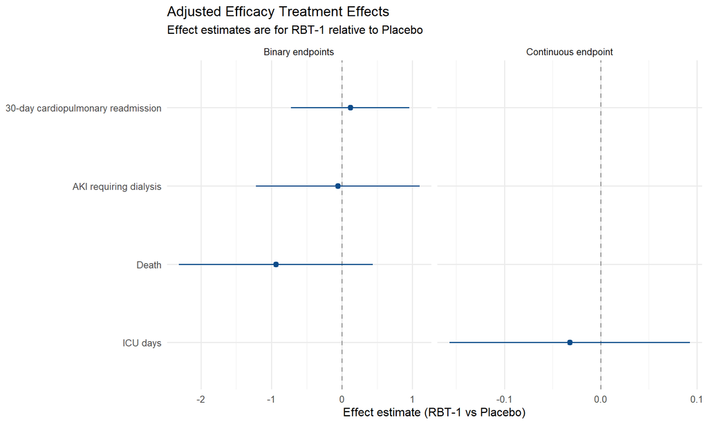

*Comment: This figure compares **RBT-1 vs Placebo**. For the binary endpoints, values to the right of the null indicate higher odds in RBT-1 and values to the left indicate lower odds in RBT-1. For ICU days, negative values indicate fewer ICU days in RBT-1 than in Placebo, and positive values indicate more ICU days in RBT-1 than in Placebo.*

# 3 Adjusted Lab Analyses

## 3.1 First-Week Longitudinal

**Adjusted First-Week Longitudinal Lab Results**

Day-by-day post-operative comparison between treatment groups across the first week

| PARAMCD | model_type | n_subjects | n_observations | Observed days | Placebo mean | RBT-1 mean | Baseline adjusted | Adj. %% difference | 95%% CI | Treatment P-value | Day Interaction P-value |
| --- | --- | --- | --- | --- | --- | --- | --- | --- | --- | --- | --- |
| GFRECRT | Mixed model, random intercept | 416 | 2602 | 1, 2, 3, 4, 5, 6, 7 | 76.78 | 79.64 | Yes | 1.4% | -2.8% to 5.8% | 0.510 | 0.707 |
| OXYSAT | Mixed model, random intercept | 407 | 411 | 1, 2 | 94.42 | 95.57 | Yes | 0.6% | -0.6% to 1.7% | 0.322 | 0.475 |
| LACTICAC | Mixed model, random intercept | 393 | 397 | 1, 2 | 2.45 | 2.55 | Yes | 0.9% | -7.6% to 10.1% | 0.842 | 0.500 |
| TROPONI | Mixed model, random intercept | 348 | 670 | 1, 2 | 5950.26 | 5619.23 | Yes | 4.3% | -19.9% to 35.7% | 0.755 | 0.130 |
| SCREAT | Mixed model, random intercept | 416 | 2602 | 1, 2, 3, 4, 5, 6, 7 | 1.03 | 1.04 | Yes | -0.7% | -2.9% to 1.6% | 0.534 | 0.785 |

*Comment: “Adj. % difference” is the model-estimated average percent difference for RBT-1 versus placebo after adjustment for post-operative day, age, and the corresponding pre-surgery laboratory value, with a random intercept for subject. Positive values indicate higher estimated laboratory values in RBT-1; negative values indicate lower estimated values in RBT-1. Because the model is fit on the log scale, these values are approximate back-transformed percent differences rather than raw arithmetic differences between the observed group means.*

## 3.2 Long-Term Follow-Up

**Adjusted Long-Term Lab Results**

Nearest available value at or after Day 28, prioritized near Day 30

| PARAMCD | n | placebo_n | rbt_n | Placebo mean | RBT-1 mean | Adj. %% difference | 95%% CI | P-value |
| --- | --- | --- | --- | --- | --- | --- | --- | --- |
| GFRECRT | 387 | 190 | 197 | 77.25 | 77.78 | -0.5% | -4.0% to 3.1% | 0.793 |
| SCREAT | 387 | 190 | 197 | 0.99 | 1.04 | 0.2% | -1.6% to 2.0% | 0.850 |

## 3.3 Availability

**Lab Data Availability by Analysis Window**

Daily first-week counts plus long-term follow-up availability

| PARAMCD | Analysis day | TRTP | subjects | Mean outcome | Median outcome |
| --- | --- | --- | --- | --- | --- |
| First-week daily |  |  |  |  |  |
| GFRECRT | 1 | Placebo | 188 | 79.27 | 82.57 |
| GFRECRT | 1 | RBT-1 | 197 | 82.80 | 86.17 |
| GFRECRT | 2 | Placebo | 204 | 77.73 | 81.26 |
| GFRECRT | 2 | RBT-1 | 212 | 79.12 | 83.74 |
| GFRECRT | 3 | Placebo | 204 | 73.96 | 79.50 |
| GFRECRT | 3 | RBT-1 | 210 | 76.48 | 82.84 |
| GFRECRT | 4 | Placebo | 203 | 76.37 | 82.22 |
| GFRECRT | 4 | RBT-1 | 212 | 79.11 | 84.96 |
| GFRECRT | 5 | Placebo | 193 | 77.96 | 85.07 |
| GFRECRT | 5 | RBT-1 | 210 | 80.53 | 86.40 |
| GFRECRT | 6 | Placebo | 163 | 77.26 | 81.21 |
| GFRECRT | 6 | RBT-1 | 169 | 80.26 | 85.73 |
| GFRECRT | 7 | Placebo | 118 | 74.12 | 75.21 |
| GFRECRT | 7 | RBT-1 | 119 | 79.35 | 87.58 |
| LACTICAC | 1 | Placebo | 199 | 2.40 | 1.80 |
| LACTICAC | 1 | RBT-1 | 209 | 2.55 | 1.65 |
| LACTICAC | 2 | Placebo | 3 | 4.37 | 3.60 |
| LACTICAC | 2 | RBT-1 | 2 | 6.85 | 6.85 |
| OXYSAT | 1 | Placebo | 203 | 94.39 | 97.00 |
| OXYSAT | 1 | RBT-1 | 212 | 95.61 | 97.70 |
| OXYSAT | 2 | Placebo | 3 | 97.00 | 97.00 |
| OXYSAT | 2 | RBT-1 | 2 | 94.50 | 94.50 |
| SCREAT | 1 | Placebo | 188 | 0.96 | 0.94 |
| SCREAT | 1 | RBT-1 | 197 | 0.94 | 0.88 |
| SCREAT | 2 | Placebo | 204 | 1.00 | 0.92 |
| SCREAT | 2 | RBT-1 | 212 | 1.02 | 0.90 |
| SCREAT | 3 | Placebo | 204 | 1.09 | 0.97 |
| SCREAT | 3 | RBT-1 | 210 | 1.10 | 0.92 |
| SCREAT | 4 | Placebo | 203 | 1.06 | 0.91 |
| SCREAT | 4 | RBT-1 | 212 | 1.06 | 0.88 |
| SCREAT | 5 | Placebo | 193 | 1.02 | 0.90 |
| SCREAT | 5 | RBT-1 | 210 | 1.04 | 0.86 |
| SCREAT | 6 | Placebo | 163 | 1.02 | 0.90 |
| SCREAT | 6 | RBT-1 | 169 | 1.04 | 0.88 |
| SCREAT | 7 | Placebo | 118 | 1.06 | 0.95 |
| SCREAT | 7 | RBT-1 | 119 | 1.11 | 0.87 |
| TROPONI | 1 | Placebo | 192 | 7121.30 | 2630.95 |
| TROPONI | 1 | RBT-1 | 198 | 6643.72 | 2586.95 |
| TROPONI | 2 | Placebo | 170 | 5139.37 | 2978.10 |
| TROPONI | 2 | RBT-1 | 184 | 5495.11 | 2980.50 |
| Long-term (>= Day 28, nearest to Day 30) |  |  |  |  |  |
| GFRECRT |  | Placebo | 190 | 77.25 | 79.36 |
| GFRECRT |  | RBT-1 | 197 | 77.78 | 81.36 |
| SCREAT |  | Placebo | 190 | 0.99 | 0.92 |
| SCREAT |  | RBT-1 | 197 | 1.04 | 0.92 |

## 3.4 Lab Forest Plot

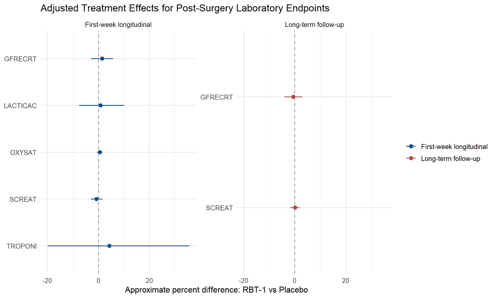

## 3.5 First-Week Trajectory Plot

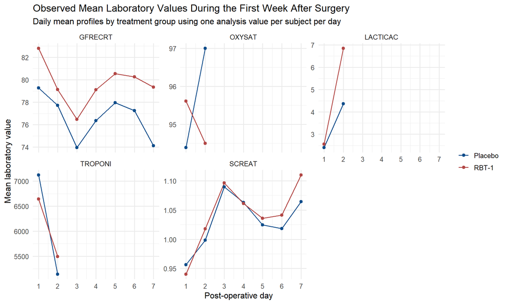

## 3.6 Adjusted Renal First-Week Profiles

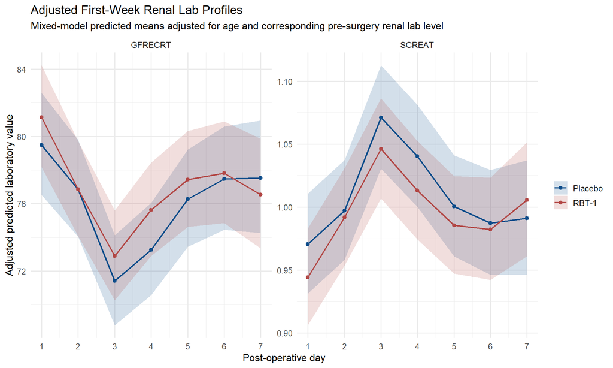

# 4 Explicit Renal Covariate Models

## 4.1 Treatment Effects

**Explicit Covariate-by-Covariate Renal Lab Models**

GFRECRT and SCREAT only, with individual ADMH and ADSC covariates

| PARAMCD | n | placebo_n | rbt_n | Observed Placebo mean | Observed RBT-1 mean | Adjusted %% difference (RBT-1 vs Placebo) | 95%% CI | P-value |
| --- | --- | --- | --- | --- | --- | --- | --- | --- |
| Immediate (Days 1-7) |  |  |  |  |  |  |  |  |
| GFRECRT | 416 | 204 | 212 | 66.60 | 67.61 | -1.1% | -7.0% to 5.2% | 0.721 |
| SCREAT | 416 | 204 | 212 | 1.22 | 1.26 | 0.5% | -2.7% to 3.9% | 0.762 |
| Long-term (>= Day 28, nearest to Day 30) |  |  |  |  |  |  |  |  |
| GFRECRT | 387 | 190 | 197 | 77.25 | 77.78 | -0.4% | -3.9% to 3.2% | 0.824 |
| SCREAT | 387 | 190 | 197 | 0.99 | 1.04 | 0.2% | -1.6% to 2.0% | 0.870 |

## 4.2 Coefficients

**Renal Model Coefficient Listing**

Full coefficient listing for explicit renal models

| PARAMCD | term | estimate | std_error | statistic | p_value |
| --- | --- | --- | --- | --- | --- |
| Immediate (Days 1-7) |  |  |  |  |  |
| GFRECRT | (Intercept) | -0.3176 | 0.4911 | -0.65 | 0.518 |
| GFRECRT | trt_ind | -0.0112 | 0.0314 | -0.36 | 0.721 |
| GFRECRT | AGE | -0.0011 | 0.0019 | -0.58 | 0.560 |
| GFRECRT | sex_male | 0.0453 | 0.0401 | 1.13 | 0.259 |
| GFRECRT | total_mh_records | -0.0035 | 0.0052 | -0.68 | 0.497 |
| GFRECRT | unique_body_systems | 0.0164 | 0.0123 | 1.34 | 0.182 |
| GFRECRT | cardiac_terms | -0.0031 | 0.0101 | -0.31 | 0.757 |
| GFRECRT | vascular_any | -0.0928 | 0.0897 | -1.04 | 0.301 |
| GFRECRT | metabolic_any | -0.0092 | 0.0557 | -0.17 | 0.869 |
| GFRECRT | respiratory_any | 0.0151 | 0.0361 | 0.42 | 0.675 |
| GFRECRT | renal_any | -0.0769 | 0.0419 | -1.84 | 0.067 |
| GFRECRT | nervous_any | -0.0574 | 0.0355 | -1.61 | 0.107 |
| GFRECRT | social_any | -0.0300 | 0.0330 | -0.91 | 0.364 |
| GFRECRT | sc_ckd_any | -0.0161 | 0.0591 | -0.27 | 0.785 |
| GFRECRT | sc_diab_any | -0.0116 | 0.0351 | -0.33 | 0.741 |
| GFRECRT | sc_hyp_any | 0.0383 | 0.0785 | 0.49 | 0.626 |
| GFRECRT | sc_cad_any | 0.0310 | 0.0319 | 0.97 | 0.332 |
| GFRECRT | sc_pad_any | 0.0076 | 0.0684 | 0.11 | 0.912 |
| GFRECRT | sc_urgent | -0.0605 | 0.0354 | -1.71 | 0.088 |
| GFRECRT | sc_hf_status | -0.0100 | 0.0446 | -0.22 | 0.822 |
| GFRECRT | sc_nyha_34 | -0.0509 | 0.0469 | -1.08 | 0.279 |
| GFRECRT | sc_lvef | 0.0003 | 0.0017 | 0.17 | 0.867 |
| GFRECRT | log1p(baseline_lab) | 1.0492 | 0.0924 | 11.35 | 0.000 |
| SCREAT | (Intercept) | 0.0038 | 0.1001 | 0.04 | 0.970 |
| SCREAT | trt_ind | 0.0051 | 0.0168 | 0.30 | 0.762 |
| SCREAT | AGE | 0.0008 | 0.0010 | 0.86 | 0.392 |
| SCREAT | sex_male | -0.0168 | 0.0230 | -0.73 | 0.464 |
| SCREAT | total_mh_records | 0.0020 | 0.0028 | 0.73 | 0.467 |
| SCREAT | unique_body_systems | -0.0085 | 0.0066 | -1.30 | 0.196 |

[output cut: 64 more lines]

## 4.3 Renal Forest Plot

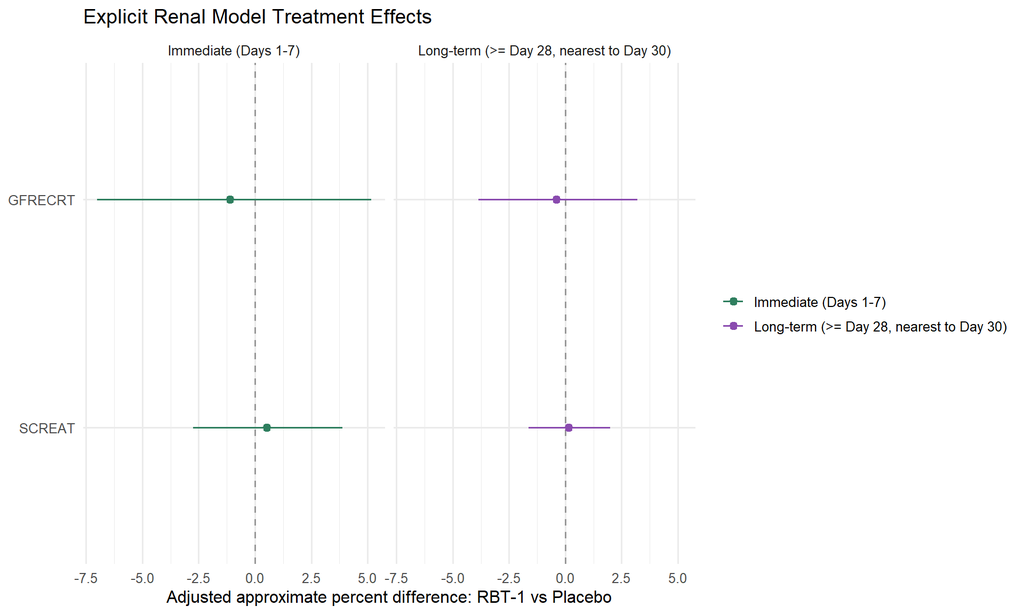

*Comment: The mean columns show the observed, unadjusted group averages. The forest plot and the “Adjusted % difference (RBT-1 vs Placebo)” column show the model-adjusted treatment effect after accounting for age, baseline renal laboratory value, and the explicit `ADMH` and `ADSC` covariates. Therefore, the adjusted effect does not have to match the direction of the raw observed mean difference. A negative value indicates that, for subjects with similar covariate values, the model estimates lower values in RBT-1 than in placebo.*